# Broussonetia RADseq Sample Missingness/MAC Filter and HWE Diagnostics

Samples retained with <=50% missing genotypes; sites retained with MAC >= 1

2026-05-06

# 1 Filtering Step

The filtered VCF was generated by first removing samples with more than 50% missing genotypes, then recalculating INFO tags on the retained samples and removing sites with MAC = 0:

```bash
Rscript scripts/render_missing50_mac1_hwe_report.R

# Inside the render script:
# 1. write reports/missing50_mac1/samples_retained_missing50.txt
# 2. subset samples, recalculate tags, and remove monomorphic sites
bcftools view \
  -S reports/missing50_mac1/samples_retained_missing50.txt \
  -Ou VCF/Broussonetia_RADseq.07_tags_refilled.vcf.gz |
bcftools +fill-tags -Ou -- \
  -t AC,AN,AF,MAF,NS,HWE,ExcHet |
bcftools view -i 'MAF>0' -Oz \
  -o VCF/filtered/Broussonetia_RADseq.08_missing50_mac1.vcf.gz
bcftools index -f VCF/filtered/Broussonetia_RADseq.08_missing50_mac1.vcf.gz

# Optional second-layer site missingness filters from the sample-filtered VCF
bcftools view -i 'F_MISSING<0.25 && MAF>0' -Oz \
  -o VCF/filtered/Broussonetia_RADseq.09_missing50_mac1_site_missing25.vcf.gz \
  VCF/filtered/Broussonetia_RADseq.08_missing50_mac1.vcf.gz
bcftools index -f VCF/filtered/Broussonetia_RADseq.09_missing50_mac1_site_missing25.vcf.gz

bcftools view -i 'F_MISSING<0.20 && MAF>0' -Oz \
  -o VCF/filtered/Broussonetia_RADseq.09_missing50_mac1_site_missing20.vcf.gz \
  VCF/filtered/Broussonetia_RADseq.08_missing50_mac1.vcf.gz
bcftools index -f VCF/filtered/Broussonetia_RADseq.09_missing50_mac1_site_missing20.vcf.gz
```

`MAF > 0` is equivalent to `MAC >= 1` for these biallelic SNPs because a positive minor allele frequency requires at least one observed copy of the minor allele after sample filtering.

# 2 Load Filtered VCF And Metadata

```r
original_vcf <- normalizePath(params$original_vcf)
filtered_vcf <- normalizePath(params$filtered_vcf)
filtered_vcf_project <- normalizePath(params$filtered_vcf_project, mustWork = FALSE)
site_missing25_vcf <- normalizePath(params$site_missing25_vcf, mustWork = FALSE)
site_missing20_vcf <- normalizePath(params$site_missing20_vcf, mustWork = FALSE)
metadata_file <- normalizePath(params$metadata_file, mustWork = FALSE)
filtered_metadata_out <- normalizePath(params$filtered_metadata_out, mustWork = FALSE)
report_out_dir <- dirname(filtered_metadata_out)
prefilter_sample_qc_file <- file.path(report_out_dir, "sample_missingness_before_missing50_filter.csv")
removed_samples_file <- file.path(report_out_dir, "samples_removed_missing50.txt")

if (!file.exists(metadata_file)) {
  stop("Metadata file does not exist: ", metadata_file)
}

vcf <- read.vcfR(filtered_vcf, verbose = FALSE)
vcf@gt[, -1] <- gsub("^([0-9.])\\|([0-9.])", "\\1/\\2", vcf@gt[, -1])

sample_ids <- colnames(vcf@gt)[-1]
prefilter_sample_qc <- read.csv(prefilter_sample_qc_file, check.names = FALSE)
removed_samples <- readLines(removed_samples_file, warn = FALSE)
site_missing25_snps <- as.integer(system2("bcftools", c("index", "-n", site_missing25_vcf), stdout = TRUE))
site_missing20_snps <- as.integer(system2("bcftools", c("index", "-n", site_missing20_vcf), stdout = TRUE))

metadata <- read.csv(metadata_file, check.names = FALSE)

if (!"Run" %in% names(metadata)) {
  stop("Metadata file does not contain a Run column: ", metadata_file)
}

for (col in c("Organism", "geo_loc_name_country", "geo_loc_name", "haplotype", "Sample Name")) {
  if (!col %in% names(metadata)) {
    metadata[[col]] <- NA_character_
  }
}

filtered_metadata <- metadata |>
  filter(Run %in% sample_ids) |>
  arrange(match(Run, sample_ids))

missing_metadata <- setdiff(sample_ids, filtered_metadata$Run)
if (length(missing_metadata) > 0) {
  stop(
    "Metadata is missing ",
    length(missing_metadata),
    " filtered VCF sample(s): ",
    paste(head(missing_metadata, 10), collapse = ", "),
    if (length(missing_metadata) > 10) ", ..."
  )
}

stopifnot(identical(filtered_metadata$Run, sample_ids))
write.csv(filtered_metadata, filtered_metadata_out, row.names = FALSE)

summary_tbl <- tibble(
  dataset = c(
    "Original VCF",
    "Samples removed",
    "Sample <=50% missing + MAC >=1",
    "Then site <25% missing",
    "Then site <20% missing",
    "Filtered metadata"
  ),
  samples = c(
    nrow(prefilter_sample_qc),
    length(removed_samples),
    length(sample_ids),
    length(sample_ids),
    length(sample_ids),
    nrow(filtered_metadata)
  ),
  snps = c(
    NA_integer_,
    NA_integer_,
    nrow(vcf@fix),
    site_missing25_snps,
    site_missing20_snps,
    NA_integer_
  )
)

datatable(summary_tbl, rownames = FALSE, options = list(dom = "t"))
```

| dataset | samples | snps |
| --- | --- | --- |
| Original VCF | 171 |  |
| Samples removed | 37 |  |
| Sample &lt;=50% missing + MAC &gt;=1 | 134 | 104027 |
| Then site &lt;25% missing | 134 | 78824 |
| Then site &lt;20% missing | 134 | 75705 |
| Filtered metadata | 134 |  |

After filtering, 134 samples and 104,027 SNPs remain. The metadata was loaded from /Users/kuowenhsi/Library/CloudStorage/OneDrive-MissouriBotanicalGarden/Broussonetia/PRJNA437223_Broussonetia_meta.csv and the filtered metadata file was written to:

/Users/kuowenhsi/Library/CloudStorage/OneDrive-MissouriBotanicalGarden/Broussonetia/reports/missing50_mac1/PRJNA437223_Broussonetia_meta.missing50_mac1.csv

The project copy of the filtered VCF is:

/Users/kuowenhsi/Library/CloudStorage/OneDrive-MissouriBotanicalGarden/Broussonetia/VCF/filtered/Broussonetia_RADseq.08_missing50_mac1.vcf.gz

The site missingness filtered VCFs are:

/Users/kuowenhsi/Library/CloudStorage/OneDrive-MissouriBotanicalGarden/Broussonetia/VCF/filtered/Broussonetia_RADseq.09_missing50_mac1_site_missing25.vcf.gz

/Users/kuowenhsi/Library/CloudStorage/OneDrive-MissouriBotanicalGarden/Broussonetia/VCF/filtered/Broussonetia_RADseq.09_missing50_mac1_site_missing20.vcf.gz

The report reads the temporary validated copy at /private/tmp/Broussonetia_RADseq.08_missing50_mac1.vcf.gz to avoid intermittent OneDrive read timeouts.

The sample missingness filter removed 37 samples with missingness >50%. Those sample IDs are written to:

/Users/kuowenhsi/Library/CloudStorage/OneDrive-MissouriBotanicalGarden/Broussonetia/reports/missing50_mac1/samples_removed_missing50.txt

```r
metadata_summary <- filtered_metadata |>
  count(geo_loc_name_country, Organism, sort = TRUE)

datatable(metadata_summary, rownames = FALSE, options = list(pageLength = 12))
```

| geo_loc_name_country | Organism | n |
| --- | --- | --- |
| China | Broussonetia papyrifera | 53 |
| Taiwan | Broussonetia papyrifera | 51 |
| Japan | Broussonetia papyrifera | 6 |
| Fiji | Broussonetia papyrifera | 5 |
| USA | Broussonetia papyrifera | 4 |
| French Polynesia | Broussonetia papyrifera | 3 |
| Tonga | Broussonetia papyrifera | 3 |
| Chile | Broussonetia papyrifera | 2 |
| Samoa | Broussonetia papyrifera | 2 |
| Indonesia | Broussonetia papyrifera | 1 |

[output cut: 4 more lines]

# 3 Missing Data By Sample

```r
gt <- extract.gt(vcf, element = "GT", as.numeric = FALSE)
called <- !is.na(gt) & gt != "./." & gt != ".|." & gt != "."
sample_missing <- colMeans(!called)
sample_called <- colSums(called)

sample_qc <- tibble(
  Run = names(sample_missing),
  missing_rate = as.numeric(sample_missing),
  called_genotypes = as.integer(sample_called)
) |>
  left_join(
    filtered_metadata |>
      select(Run, Organism, geo_loc_name_country, geo_loc_name, haplotype, `Sample Name`),
    by = "Run"
  ) |>
  arrange(desc(missing_rate))

write.csv(
  sample_qc,
  file.path(report_out_dir, "sample_missingness_after_missing50_mac1.csv"),
  row.names = FALSE
)

datatable(sample_qc, rownames = FALSE, options = list(pageLength = 15))
```

| Run | missing_rate | called_genotypes | Organism | geo_loc_name_country | geo_loc_name | haplotype | Sample Name |
| --- | --- | --- | --- | --- | --- | --- | --- |
| SRR12425464 | 0.2771876532054178 | 75192 | Broussonetia papyrifera | Philippines | Philippines: Los Banos\, Laguna\, Luzon | cp43 | KFC2018_3_Philippines_Luzon_cp43 |
| SRR12425444 | 0.2586155517317619 | 77124 | Broussonetia papyrifera | China | China: Longhai\, Zhangzhou\, Fujian Province | cp01 | LYH100_3_Fujian_Zhangzhou_cp01 |
| SRR12425411 | 0.2544531708114239 | 77557 | Broussonetia papyrifera | Taiwan | Taiwan: Machu\, Lianjiang County\, Fujian Province | cp46 | KFC2418_Fujian_Lianjiang_Machu_cp46 |
| SRR12425373 | 0.2494352427735107 | 78079 | Broussonetia papyrifera | Taiwan | Taiwan: Fangshan Township\, Pingtung County | cp17 | M81_4_Taiwan_Pingtung_cp17 |
| SRR12425526 | 0.2493006623280495 | 78093 | Broussonetia papyrifera | China | China: Longzhou\, Chongzuo\, Guangxi Province | cp39 | Peng22951_3_Guangxi_Chongzuo_cp39 |
| SRR12425483 | 0.2482336316533208 | 78204 | Broussonetia papyrifera | Taiwan | Taiwan: Pitou Township\, Changhua County | cp13 | KFC3439_1_Taiwan_Changhua_cp13 |
| SRR12425405 | 0.2479452449844752 | 78234 | Broussonetia papyrifera | China | China: Shanghai Chenshan Botanical Garden\, Songjiang\, Shanghai City | cp01 | xy005092_1_Shanghai_cp01 |
| SRR12425525 | 0.2428696396127928 | 78762 | Broussonetia papyrifera | China | China: Longzhou\, Chongzuo\, Guangxi Province | cp34 | Peng22965_3_Guangxi_Chongzuo_cp34 |
| SRR12425398 | 0.2428600267238313 | 78763 | Broussonetia papyrifera | China | China: Mengyin\, Linyi\, Shandong Province | cp40 | CY160123_1_Shandong_Linyi_cp40 |
| SRR12425458 | 0.2417353187153335 | 78880 | Broussonetia papyrifera | Taiwan | Taiwan: Yujing District\, Tainan City | cp16 | NYJ02_1_Taiwan_Tainan_cp16 |

[output cut: 124 more lines]

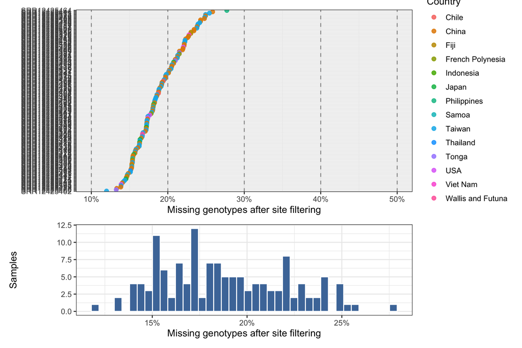

```r
p_sample_rank <- sample_qc |>
  mutate(Run = fct_reorder(Run, missing_rate)) |>
  ggplot(aes(Run, missing_rate, color = geo_loc_name_country)) +
  geom_point(size = 2.1, alpha = 0.85) +
  geom_hline(yintercept = c(0.1, 0.2, 0.3, 0.4, 0.5), linetype = "dashed", color = "grey60") +
  coord_flip() +
  scale_y_continuous(labels = percent) +
  labs(x = NULL, y = "Missing genotypes after site filtering", color = "Country")

p_sample_hist <- sample_qc |>
  ggplot(aes(missing_rate)) +
  geom_histogram(bins = 40, fill = "#4C78A8", color = "white") +
  scale_x_continuous(labels = percent) +
  labs(x = "Missing genotypes after site filtering", y = "Samples")

p_sample_rank / p_sample_hist + plot_layout(heights = c(2, 1))
```

```r
sample_thresholds <- tibble(max_sample_missing = c(0.1, 0.2, 0.3, 0.4, 0.5))

sample_threshold_summary <- sample_thresholds |>
  mutate(
    samples_retained = map_int(max_sample_missing, ~ sum(sample_qc$missing_rate <= .x)),
    samples_removed = length(sample_ids) - samples_retained
  )

datatable(sample_threshold_summary, rownames = FALSE, options = list(dom = "t"))
```

| max_sample_missing | samples_retained | samples_removed |
| --- | --- | --- |
| 0.1 | 0 | 134 |
| 0.2 | 87 | 47 |
| 0.3 | 134 | 0 |
| 0.4 | 134 | 0 |
| 0.5 | 134 | 0 |

# 4 Hardy-Weinberg Diagnostics

For each SNP, this report compares reference allele frequency against the observed heterozygote genotype frequency. A simple Hardy-Weinberg expectation curve, `2pq`, is added as a reference. Because this dataset spans multiple geographic and taxonomic groups, global HWE filtering should be treated cautiously: population structure can create deviations from HWE even when genotypes are technically sound.

```r
gt_num <- gt
gt_num[gt_num %in% c("0/0")] <- "0"
gt_num[gt_num %in% c("0/1", "1/0")] <- "1"
gt_num[gt_num %in% c("1/1")] <- "2"
gt_numeric <- matrix(as.numeric(gt_num), nrow = nrow(gt_num), dimnames = dimnames(gt))

n_called <- rowSums(called)
n_het <- rowSums(gt == "0/1" | gt == "1/0", na.rm = TRUE)
alt_allele_count <- rowSums(gt_numeric, na.rm = TRUE)
allele_number <- 2 * n_called
alt_freq <- alt_allele_count / allele_number
ref_freq <- 1 - alt_freq
het_freq <- n_het / n_called
mac <- pmin(alt_allele_count, allele_number - alt_allele_count)

info <- vcfR2tidy(vcf, info_only = TRUE)$fix |>
  as_tibble() |>
  mutate(row_id = row_number())

hwe_df <- tibble(
  row_id = seq_len(nrow(vcf@fix)),
  chrom = vcf@fix[, "CHROM"],
  pos = as.integer(vcf@fix[, "POS"]),
  ref = vcf@fix[, "REF"],
  alt = vcf@fix[, "ALT"],
  n_called = n_called,
  n_het = n_het,
  mac = mac,
  ref_freq = ref_freq,
  alt_freq = alt_freq,
  het_freq = het_freq,
  expected_het_freq = 2 * ref_freq * (1 - ref_freq)
) |>
  left_join(info |> select(row_id, HWE, ExcHet), by = "row_id") |>
  mutate(
    HWE = as.numeric(HWE),
    ExcHet = as.numeric(ExcHet),
    hwe_neglog10 = -log10(pmax(HWE, .Machine$double.xmin))
  )

write.csv(
  hwe_df,
  file.path(report_out_dir, "hwe_site_summary_after_missing50_mac1.csv"),
  row.names = FALSE
)

datatable(
  hwe_df |>
    select(chrom, pos, ref, alt, n_called, mac, ref_freq, het_freq, HWE, ExcHet) |>
    arrange(HWE),
  rownames = FALSE,
  options = list(pageLength = 12)
)
```

| chrom | pos | ref | alt | n_called | mac | ref_freq | het_freq | HWE | ExcHet |
| --- | --- | --- | --- | --- | --- | --- | --- | --- | --- |
| scaffold_6 | 12961977 | G | T | 129 | 129 | 0.5 | 1 | 2.96088e-38 | 2.96088e-38 |
| scaffold_6 | 12961988 | C | T | 129 | 129 | 0.5 | 1 | 2.96088e-38 | 2.96088e-38 |
| scaffold_1 | 21533634 | T | C | 105 | 105 | 0.5 | 1 | 4.48267e-31 | 4.48267e-31 |
| scaffold_11 | 11908197 | C | T | 104 | 104 | 0.5 | 1 | 9.61908e-31 | 8.92265e-31 |
| scaffold_7 | 2344134 | C | T | 117 | 114 | 0.4871794871794872 | 0.9572649572649573 | 3.33546e-27 | 3.26884e-27 |
| scaffold_5 | 22582173 | C | T | 82 | 82 | 0.5 | 1 | 3.61618e-24 | 3.32418e-24 |
| scaffold_5 | 10297355 | G | A | 90 | 88 | 0.5111111111111111 | 0.9777777777777777 | 1.89573e-23 | 1.42344e-23 |
| scaffold_10 | 4196769 | G | A | 74 | 74 | 0.5 | 1 | 8.83287e-22 | 8.08546e-22 |
| scaffold_10 | 4196765 | A | G | 73 | 73 | 0.5 | 1 | 1.60617e-21 | 1.60617e-21 |
| scaffold_1 | 44973792 | A | C | 99 | 92 | 0.4646464646464646 | 0.9292929292929293 | 8.56353e-21 | 5.30418e-21 |

[output cut: 104017 more lines]

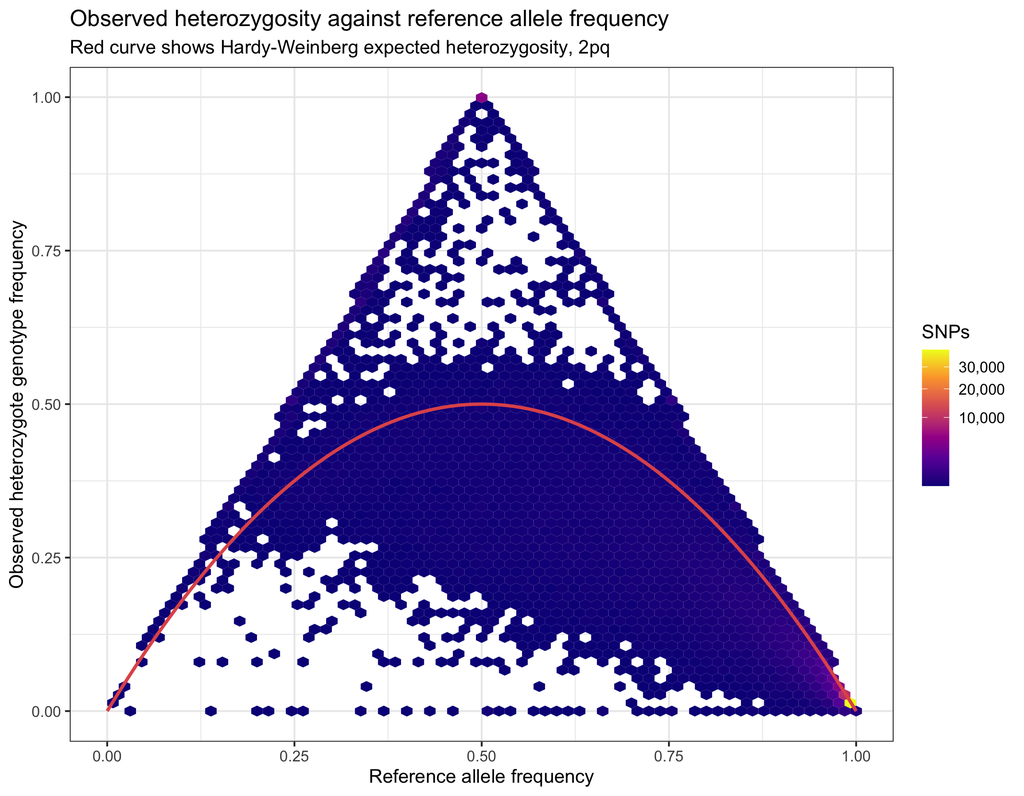

```r
expected_curve <- tibble(ref_freq = seq(0, 1, length.out = 300)) |>
  mutate(expected_het_freq = 2 * ref_freq * (1 - ref_freq))

hwe_df |>
  ggplot(aes(ref_freq, het_freq)) +
  geom_hex(bins = 65) +
  geom_line(
    data = expected_curve,
    aes(ref_freq, expected_het_freq),
    inherit.aes = FALSE,
    color = "#E15759",
    linewidth = 1
  ) +
  scale_fill_viridis_c(option = "C", trans = "sqrt", labels = comma) +
  labs(
    x = "Reference allele frequency",
    y = "Observed heterozygote genotype frequency",
    fill = "SNPs",
    title = "Observed heterozygosity against reference allele frequency",
    subtitle = "Red curve shows Hardy-Weinberg expected heterozygosity, 2pq"
  )
```

```r
hwe_thresholds <- tibble(
  hwe_p_min = c(0, 1e-8, 1e-6, 1e-5, 1e-4, 1e-3, 1e-2, 5e-2)
) |>
  mutate(
    threshold_label = if_else(hwe_p_min == 0, "none", paste0("HWE p >= ", format(hwe_p_min, scientific = TRUE))),
    snps_retained = map_int(hwe_p_min, ~ sum(hwe_df$HWE >= .x, na.rm = TRUE)),
    snps_removed = nrow(hwe_df) - snps_retained,
    percent_retained = snps_retained / nrow(hwe_df)
  )

datatable(hwe_thresholds, rownames = FALSE, options = list(dom = "t"))
```

| hwe_p_min | threshold_label | snps_retained | snps_removed | percent_retained |
| --- | --- | --- | --- | --- |
| 0 | none | 104027 | 0 | 1 |
| 1e-08 | HWE p &gt;= 1e-08 | 102188 | 1839 | 0.9823218971997655 |
| 1e-06 | HWE p &gt;= 1e-06 | 99933 | 4094 | 0.9606448325915388 |
| 1e-05 | HWE p &gt;= 1e-05 | 98009 | 6018 | 0.942149634229575 |
| 0.0001 | HWE p &gt;= 1e-04 | 95044 | 8983 | 0.9136474184586694 |
| 0.001 | HWE p &gt;= 1e-03 | 90042 | 13985 | 0.8655637478731483 |
| 0.01 | HWE p &gt;= 1e-02 | 82859 | 21168 | 0.796514366462553 |
| 0.05 | HWE p &gt;= 5e-02 | 73473 | 30554 | 0.70628779066973 |

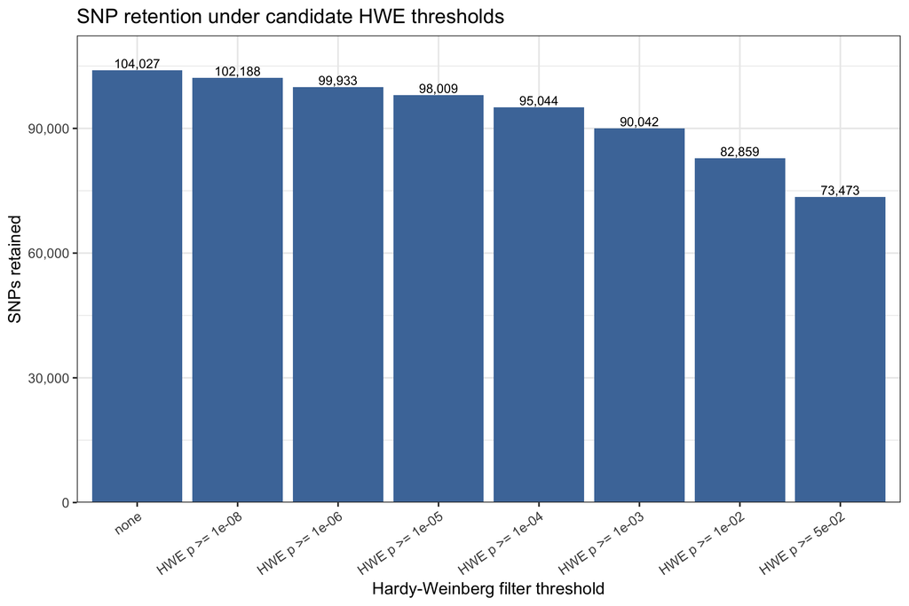

```r
hwe_thresholds |>
  mutate(threshold_label = factor(threshold_label, levels = threshold_label)) |>
  ggplot(aes(threshold_label, snps_retained)) +
  geom_col(fill = "#4C78A8") +
  geom_text(aes(label = comma(snps_retained)), vjust = -0.25, size = 3.2) +
  scale_y_continuous(labels = comma, expand = expansion(mult = c(0, 0.08))) +
  labs(
    x = "Hardy-Weinberg filter threshold",
    y = "SNPs retained",
    title = "SNP retention under candidate HWE thresholds"
  ) +
  theme(axis.text.x = element_text(angle = 35, hjust = 1))
```

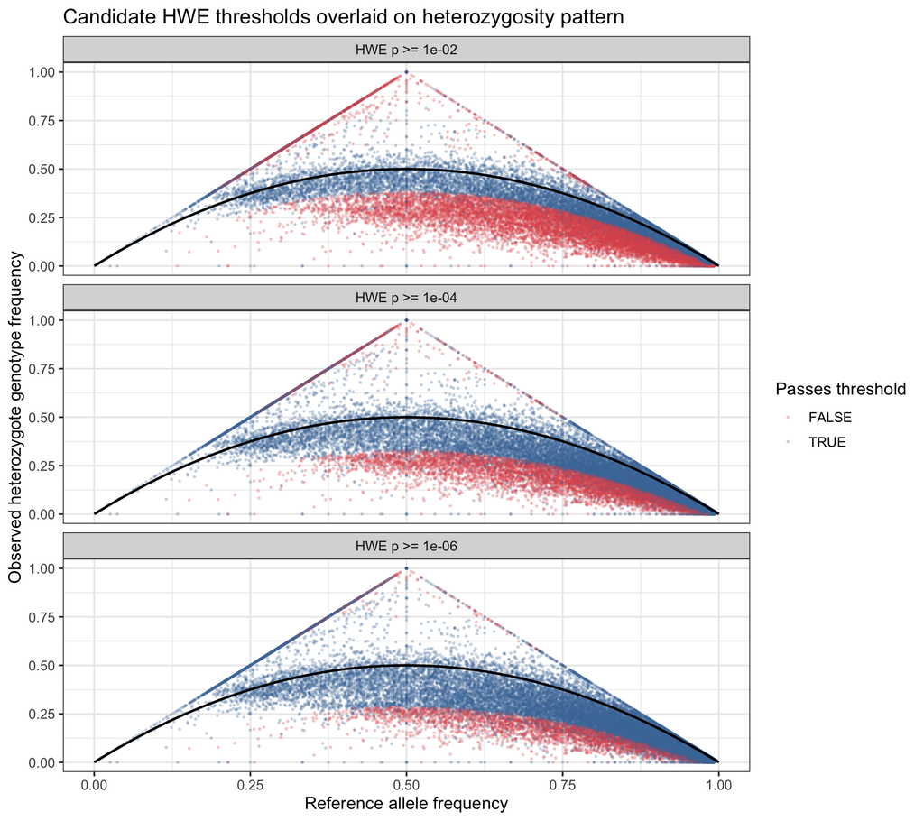

```r
plot_thresholds <- c(1e-6, 1e-4, 1e-2)

hwe_overlay <- crossing(
  hwe_df |> select(ref_freq, het_freq, HWE),
  hwe_p_min = plot_thresholds
) |>
  mutate(
    threshold = paste0("HWE p >= ", format(hwe_p_min, scientific = TRUE)),
    passes = HWE >= hwe_p_min
  )

hwe_overlay |>
  ggplot(aes(ref_freq, het_freq, color = passes)) +
  geom_point(alpha = 0.22, size = 0.35) +
  geom_line(
    data = expected_curve,
    aes(ref_freq, expected_het_freq),
    inherit.aes = FALSE,
    color = "black",
    linewidth = 0.8
  ) +
  facet_wrap(~ threshold, ncol = 1) +
  scale_color_manual(values = c(`FALSE` = "#E15759", `TRUE` = "#4C78A8")) +
  labs(
    x = "Reference allele frequency",
    y = "Observed heterozygote genotype frequency",
    color = "Passes threshold",
    title = "Candidate HWE thresholds overlaid on heterozygosity pattern"
  )
```